# 第6回 分類の判定を、混同行列で評価する（1行ずつ読む版）

迷惑メッセージを、どう見分け、どう評価するか

# 導入

## 第5回は肉、今日はメッセージ

① 今日のデータ●

- 第5回は、肉に当てた光のスペクトル（数の列が100本）を使った
- 今日は、携帯電話に届いたメッセージの文章を使う
- 数の表ではなく、文章。データに合わせて、道具を組み立て直す

## 迷惑メッセージは、毎日届く

② 場面●○○

- 「当選しました。この番号に電話を」のような迷惑メッセージ（spam）
- 携帯電話の会社やアプリは、届く前に迷惑フォルダへ振り分けている
- 振り分ける仕組みを、迷惑メッセージのフィルターと呼ぶ

## 決めたいこと

② 場面●●○

- 届いたメッセージの本文から、迷惑か普通かを判定したい
- 答えは2つのうちのどちらか。量ではなく、2択を当てる（分類）
- 作ったフィルターが、どのくらい良いかも評価したい

## 2つの誤り

② 場面●●●

- 迷惑メッセージを通してしまう（見逃し）
- 大事な連絡を、迷惑フォルダに入れてしまう（誤検出）
- どちらも困る。でも、困り方は違う

## 手元のデータ

③ 手元のデータ●○○○

- SMS Spam Collection：研究のために集めた、英語のSMS 5,574通
- 1行が1通。列は本文と、迷惑（spam）か普通（ham）かのラベル
- 迷惑は、英国の利用者が掲示板に投稿したもの。普通は、大学生が提供したもの

## データをのぞく

③ 手元のデータ●●○○

|  | label | text |
| --- | --- | --- |
| 0 | ham | Go until jurong point, crazy.. Available onl... |
| 1 | ham | Ok lar... Joking wif u oni... |
| 2 | spam | Free entry in 2 a wkly comp to win FA Cup fi... |
| 3 | ham | U dun say so early hor... U c already then s... |
| 4 | ham | Nah I don't think he goes to usf, he lives a... |

- 1通の本文は、短い英語の文章。略語や打ち間違いも多い

## 迷惑メッセージの例

③ 手元のデータ●●●○

```
FREE entry into our £250 weekly competition just text the word WIN to 80086 NOW. 18 T&C www.txttowin.co.uk
You have won ?1,000 cash or a ?2,000 prize! To claim, call09050000327
```

- 「無料」「当選」「すぐ電話を」と、番号が並ぶ

## 普通のメッセージの例

③ 手元のデータ●●●●

```
Tired. I haven't slept well the past few nights.
Are you free now?can i call now?
```

- 友だちどうしの短いやりとり。freeやcallも出てくる

## 最後に出す答え

④ 今日の問い●○

- 迷惑メッセージを、どれだけ捕まえ、普通のメッセージをどれだけ誤って捕まえるか
- そのフィルターを、どんな数で評価すればよいか

## 今日の問い

④ 今日の問い●●

本文から、迷惑メッセージをどう見分け、その見分け方をどう評価するか？

## もう1つのねらい：if

⑤ もう1つのねらい●

- 条件で処理を分ける書き方（if）を使い、ルールや判定のコードを読めるようになる
- 「freeを含むなら迷惑」「数字が5字以上なら迷惑」を、ifで書く
- お手本ごとに、コードを1行ずつ読み、変数の中身を見る

# 今日の一周

## 結果だけで一度通す

⑥ 今日の一周●○○○○○○○○

- まず、今日の解析を、結果だけで一度通して見る
- コードはあとで。どんな結論になるかを先に知っておく

## 一周①：ルールで見分ける

⑥ 今日の一周●●○○○○○○○

```
freeを含むなら迷惑、のルールの正解率 0.894
```

- 「freeを含むなら迷惑」と判定すると、89%のメッセージで当たる

## 一周②：何もしなくても87%

⑥ 今日の一周●●●○○○○○○

```
何も迷惑と言わないルールの正解率 0.874
```

- 全部を「普通」と答えても、正解率は0.874。正解率だけでは分からない

## 一周③：4つのマスで数える

⑥ 今日の一周●●●●○○○○○

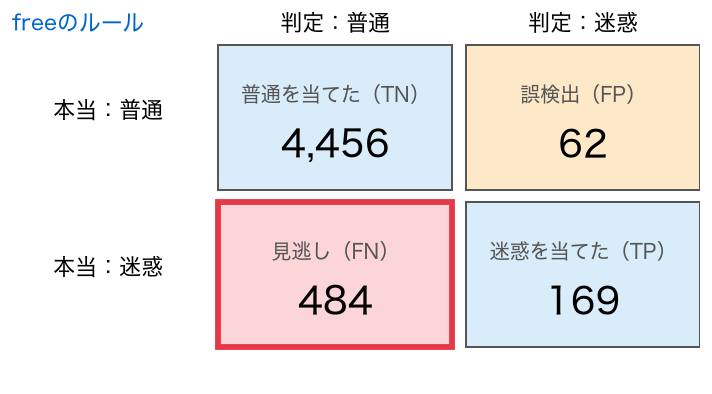

- freeのルールは、迷惑653通のうち484通を見逃している

## 一周④：数字を数える

⑥ 今日の一周●●●●●○○○○

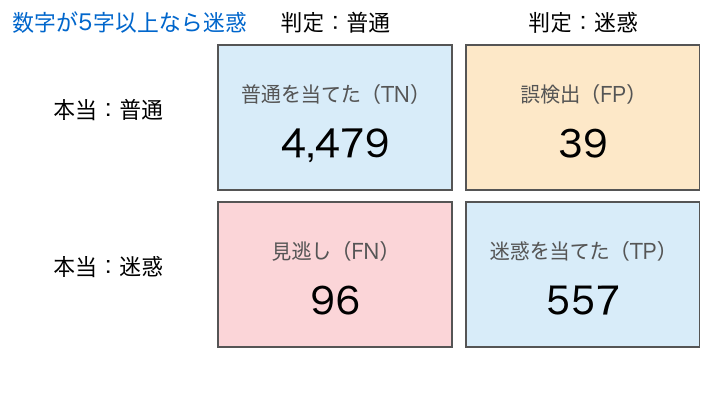

- 本文の数字を数え、5字以上なら迷惑。見逃し96、誤検出39まで減る

## 一周⑤：手がかりをまとめて確率に

⑥ 今日の一周●●●●●●○○○

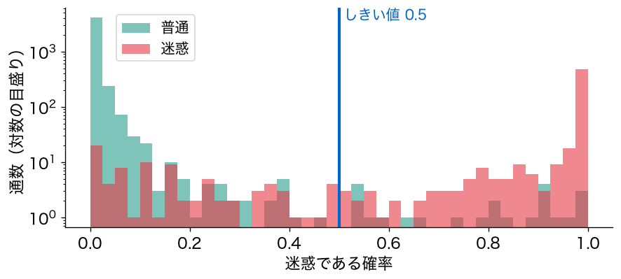

```
0.5で切ると 見逃し 83  誤検出 23
```

- 数字と15語から、ロジスティック回帰で迷惑である確率を出す
- 0.5で切ると、見逃し・誤検出とも、数字のルール（96・39）より少ない

## 一周⑥：しきい値を動かす

⑥ 今日の一周●●●●●●●○○

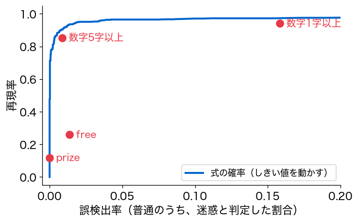

```
AUC 0.981
```

- 切る場所（しきい値）で、見逃しと誤検出が入れ替わる
- 全部のしきい値を1本の線（ROC曲線）に。下の面積がAUC

## 一周⑦：えっ、確率ほぼ0の迷惑

⑥ 今日の一周●●●●●●●●○

```
24 通
0.03 Did you hear about the new "Divorce Barbie"? It comes with
0.027 Do you realize that in about 40 years, we'll have thousand
```

- 迷惑なのに、迷惑である確率が0.05より小さい通が24通ある
- しきい値をどこに動かしても、捕まえられない

## 一周は5つの段

⑥ 今日の一周●●●●●●●●●

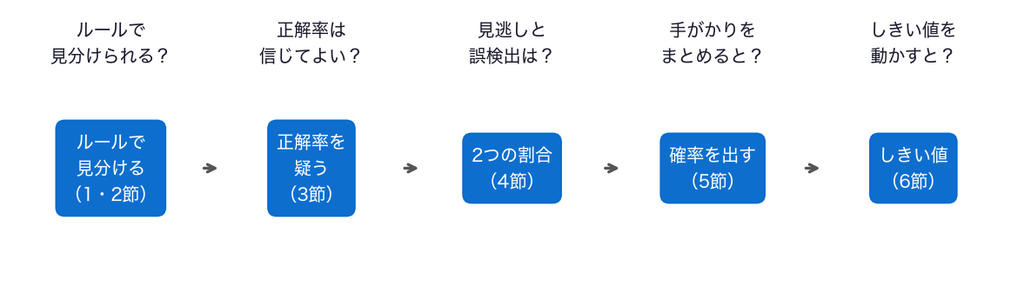

- このあと、5つの段の中身を、1つずつ開けていく

## 問いとやること①②

⑦ 問いとやること●○

- ルールで見分ける：ルールで見分けられる？ → 「freeを含むなら迷惑」をifで書き、正解率を測る（1・2節）
- 正解率を疑う：正解率は信じてよい？ → 何も迷惑と言わないルールと比べ、4つのマスを数える（3節）

## 問いとやること③④⑤

⑦ 問いとやること●●

- 2つの割合：見逃しと誤検出は？ → 再現率と適合率を出し、数字を数えるルールと比べる（4節）
- 確率を出す：手がかりをまとめると？ → 数字と15語でロジスティック回帰の確率を出し、0.5で切る（5節）
- しきい値：動かすと？ → 切る場所を動かし、ROC曲線とAUCで測る。見逃した迷惑を読む（6節）

## 今日の進め方

⑧ 今日の進め方●

- 段ごとに、スライドで聞く → ノートで実行して答える
- 段の終わりの「ノートへ」で、予想を書き、1か所を替えて実行し、予想と比べる
- 予想は外れてかまわない

# 0. 準備

## まずは道具とデータ

- 0節は、ノートで1節と続けて実行する
- 道具を呼び出す → 表を読み込む → 同じ本文を1通にまとめる

## お手本：表を整える

0節 ① 表を整える●○○○○○

```python
df = raw.drop_duplicates('text').reset_index(drop=True)
df = df.rename(columns={'text': '本文'})
df['迷惑'] = (df['label'] == 'spam').astype(int)
print(len(raw), '通 →', len(df), '通')
print(df['迷惑'].sum(), '通が迷惑')
```

```
5574 通 → 5171 通
653 通が迷惑
```

- `drop_duplicates('text')`：同じ本文の行を、1行だけ残して消す

## 1行ずつ：表を整える①

0節 ① 表を整える●●○○○○

```python
df = raw.drop_duplicates('text').reset_index(drop=True)
df = df.rename(columns={'text': '本文'})
df['迷惑'] = (df['label'] == 'spam').astype(int)
print(len(raw), '通 →', len(df), '通')
print(df['迷惑'].sum(), '通が迷惑')
```

- 1行目：`raw`から、同じ本文の行を1行だけ残して消す（`drop_duplicates`）
- 続けて`reset_index(drop=True)`で、行の番号を0から振り直し、`df`にしまう
- 番号を振り直すと、行の番号が0から抜けなく並ぶ

## 1行ずつ：表を整える②

0節 ① 表を整える●●●○○○

```python
df = raw.drop_duplicates('text').reset_index(drop=True)
df = df.rename(columns={'text': '本文'})
df['迷惑'] = (df['label'] == 'spam').astype(int)
print(len(raw), '通 →', len(df), '通')
print(df['迷惑'].sum(), '通が迷惑')
```

- 2行目：列の名前textを、本文に替える（`rename`）
- 3行目：labelがspamならTrue、違えばFalse。`astype(int)`で1と0に直し、列「迷惑」にしまう

## 1行ずつ：表を整える③

0節 ① 表を整える●●●●○○

```python
df = raw.drop_duplicates('text').reset_index(drop=True)
df = df.rename(columns={'text': '本文'})
df['迷惑'] = (df['label'] == 'spam').astype(int)
print(len(raw), '通 →', len(df), '通')
print(df['迷惑'].sum(), '通が迷惑')
```

- 4行目：`len(表)`は行の数。整える前と後の通数を並べて出す
- 5行目：1と0の列の合計は、1の数。つまり迷惑の通数

## 中身を見る：列「迷惑」

0節 ① 表を整える●●●●●○

```python
df[['label', '迷惑']].head(3)
```

|  | label | 迷惑 |
| --- | --- | --- |
| 0 | ham | 0 |
| 1 | ham | 0 |
| 2 | spam | 1 |

- spamの行だけが1、hamの行は0になった

## 迷惑なら1、普通なら0

0節 ① 表を整える●●●●●●

- 同じ本文が何度も届いた分を1通にまとめ、5,171通にした
- 列「迷惑」は、迷惑なら1、普通なら0。答えの列になる
- `(df['label'] == 'spam')`はTrue/Falseの列。`astype(int)`で1/0に直す

# 1. どんなメッセージが届く？

## 段1：ルールで見分ける

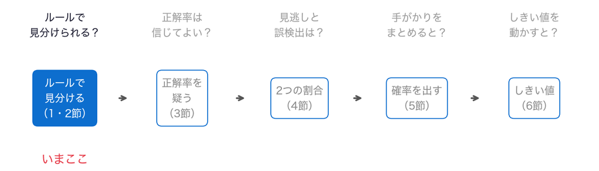

- 問い：簡単なルールで、迷惑メッセージを見分けられるか
- まず、迷惑がどのくらいの割合で届いているかを見る

## お手本：迷惑の割合

1節 ① 迷惑の割合●○○

```python
print(df['迷惑'].value_counts())
print(round(df['迷惑'].mean(), 3))
```

```
迷惑
0    4518
1     653
0.126
```

- `mean()`：1/0の列の平均は、1の割合

## 1行ずつ：迷惑の割合

1節 ① 迷惑の割合●●○

```python
print(df['迷惑'].value_counts())
print(round(df['迷惑'].mean(), 3))
```

- 1行目：`value_counts()`は、値ごとに行の数を数える。0（普通）と1（迷惑）の通数
- 2行目：`mean()`は平均。1と0の列の平均は、1の割合
- `round(…, 3)`で、小数第3位までに丸める

## 8通に1通が迷惑

1節 ① 迷惑の割合●●●

- 5,171通のうち、迷惑は653通、普通は4,518通
- 迷惑の割合は0.126。8通に1通ほど
- 少ない側を見つけたい。この偏りが、今日の話の鍵になる

## お手本：迷惑の本文を読む

1節 ② 本文を読む●○○

```python
df[df['迷惑'] == 1]['本文'].head()
```

```
2     Free entry in 2 a wkly comp to win FA Cup fi...
5     FreeMsg Hey there darling it's been 3 week's...
8     WINNER!! As a valued network customer you ha...
9     Had your mobile 11 months or more? U R entit...
11    SIX chances to win CASH! From 100 to 20,000 ...
Name: 本文, dtype: object
```

- 迷惑の行だけを取り出し、本文の列の先頭5通を見る

## 1行ずつ：迷惑の本文を読む

1節 ② 本文を読む●●○

```python
df[df['迷惑'] == 1]['本文'].head()
```

- `df['迷惑'] == 1`：迷惑ならTrue、普通ならFalseの列
- `df[Trueの列]`：Trueの行だけを取り出した表
- `['本文']`で本文の列を取り出し、`head()`で先頭の5通を見る

## 迷惑には、決まり文句がある

1節 ② 本文を読む●●●

- free（無料）、win（当選）、claim（受け取る）、call（電話を）
- 電話番号や短い番号が並ぶ
- この特徴を、ルールにできないか

# 2. ルールで見分けられる？

## 「freeを含むなら迷惑」

- 迷惑の本文には、freeがよく出てくる
- そこで、本文にfreeを含むなら迷惑、含まないなら普通、と判定する
- 条件によって、答えを分けたい

## 道具：文字列の中に語があるか

2節 ① 道具●○

```python
print('free' in 'Are you free now?')   # True
print('free' in 'Tired.')              # False
```

- `語 in 文字列`：文字列の中にその語があればTrue、なければFalse

## 道具：小文字にそろえる

2節 ① 道具●●

```python
print('FREE entry'.lower())            # free entry
```

- `lower()`：大文字を小文字にそろえる。FREEもFreeも、freeとして探せる

## 新しい書き方：if

2節 ② if●

```python
x = 7
if x >= 5:
    print('5以上')     # 条件がTrueのときだけ動く
else:
    print('5未満')     # 条件がFalseのときだけ動く
```

- `if 条件:`の下の字下げした行は、条件がTrueのときだけ動く
- `else:`の下の行は、条件がFalseのときだけ動く

## お手本：ルールの関数

2節 ③ ルールの関数●○○○○○○

```python
def rule(text, word):
    if word in text.lower():
        return 1          # 迷惑と判定
    else:
        return 0          # 普通と判定

print(rule('FREE entry into our weekly comp', 'free'))
print(rule('Tired. I have not slept well', 'free'))
```

```
1
0
```

## 1行ずつ：ルールの関数①

2節 ③ ルールの関数●●○○○○○

```python
def rule(text, word):
    if word in text.lower():
        return 1          # 迷惑と判定
    else:
        return 0          # 普通と判定

print(rule('FREE entry into our weekly comp', 'free'))
print(rule('Tired. I have not slept well', 'free'))
```

- 1行目：関数`rule`を作る。入力は本文`text`と、探す語`word`の2つ
- `def`の下の字下げした行が、関数の中身。呼び出したときに動く

## 1行ずつ：ルールの関数②

2節 ③ ルールの関数●●●○○○○

```python
def rule(text, word):
    if word in text.lower():
        return 1          # 迷惑と判定
    else:
        return 0          # 普通と判定

print(rule('FREE entry into our weekly comp', 'free'))
print(rule('Tired. I have not slept well', 'free'))
```

- 2行目：本文を小文字にそろえ（`text.lower()`）、その中に`word`があるかを調べる
- あればTrue、なければFalse。これが`if`の条件

## 1行ずつ：ルールの関数③

2節 ③ ルールの関数●●●●○○○

```python
def rule(text, word):
    if word in text.lower():
        return 1          # 迷惑と判定
    else:
        return 0          # 普通と判定

print(rule('FREE entry into our weekly comp', 'free'))
print(rule('Tired. I have not slept well', 'free'))
```

- 3行目：条件がTrueのとき、1を返す（迷惑と判定）
- 4・5行目：条件がFalseのとき、0を返す（普通と判定）
- `return`は、関数の答えを返して、関数を終える

## 1行ずつ：ルールの関数④

2節 ③ ルールの関数●●●●●○○

```python
def rule(text, word):
    if word in text.lower():
        return 1          # 迷惑と判定
    else:
        return 0          # 普通と判定

print(rule('FREE entry into our weekly comp', 'free'))
print(rule('Tired. I have not slept well', 'free'))
```

- 7行目：FREEを含む本文で呼ぶ。小文字にするとfreeを含むので1
- 8行目：freeを含まない本文で呼ぶ。0

## 中身を見る：条件の中身

2節 ③ ルールの関数●●●●●●○

```python
text = 'Call FREEPHONE 0800 542 0578 now!'
print(text.lower())
print('free' in text.lower())
print(rule(text, 'free'))
```

```
call freephone 0800 542 0578 now!
True
1
```

- 小文字にすると、freephoneの中にfreeが入っている。だからTrueで、1

## ifの分かれ道

2節 ③ ルールの関数●●●●●●●

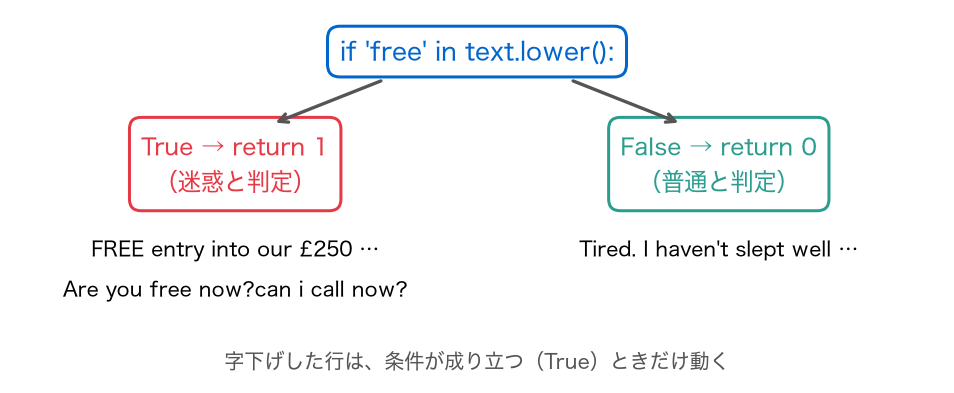

- 1通ずつ、条件で道が分かれる。「Are you free now?」も、迷惑の道へ進む

## お手本：全部の通に判定を付ける

2節 ④ 判定を付ける●○○○○

```python
pred = []
for text in df['本文']:
    pred.append(rule(text, 'free'))
df['判定'] = pred
print(df['判定'].sum(), '通を迷惑と判定')
```

```
231 通を迷惑と判定
```

- 1通ずつ`rule`で判定し、リストにためて（第4回）、列「判定」にする

## 1行ずつ：判定を付ける①

2節 ④ 判定を付ける●●○○○

```python
pred = []
for text in df['本文']:
    pred.append(rule(text, 'free'))
df['判定'] = pred
print(df['判定'].sum(), '通を迷惑と判定')
```

- 1行目：空のリスト`pred`を作る。ここに判定をためていく
- 2行目：列「本文」から1通ずつ取り出して`text`に入れ、字下げした行をくり返す

## 1行ずつ：判定を付ける②

2節 ④ 判定を付ける●●●○○

```python
pred = []
for text in df['本文']:
    pred.append(rule(text, 'free'))
df['判定'] = pred
print(df['判定'].sum(), '通を迷惑と判定')
```

- 3行目：その1通を`rule`で判定し（1か0）、`pred`の後ろに足す（`append`）
- 5,171回くり返すと、`pred`には5,171個の1と0が並ぶ

## 1行ずつ：判定を付ける③

2節 ④ 判定を付ける●●●●○

```python
pred = []
for text in df['本文']:
    pred.append(rule(text, 'free'))
df['判定'] = pred
print(df['判定'].sum(), '通を迷惑と判定')
```

- 4行目：リスト`pred`を、表の列「判定」にする
- 5行目：1と0の列の合計は、迷惑と判定した通数

## 中身を見る：3通だけ回す

2節 ④ 判定を付ける●●●●●

```python
pred = []
for text in df['本文'].head(3):
    pred.append(rule(text, 'free'))
    print(pred)
```

```
[0]
[0, 0]
[0, 0, 1]
```

- 1回ごとに、後ろに1つ足される。3通めはFreeで始まるので1

## お手本：正解率

2節 ⑤ 正解率●○○○○

```python
from sklearn.metrics import accuracy_score
print(round(accuracy_score(df['迷惑'], df['判定']), 3))
```

```
0.894
```

$$\text{正解率} = \frac{\text{判定が当たった通数}}{\text{全部の通数}}$$

- `accuracy_score(本当, 判定)`：正解率を返す道具（`sklearn`）

## 1行ずつ：正解率

2節 ⑤ 正解率●●○○○

```python
from sklearn.metrics import accuracy_score
print(round(accuracy_score(df['迷惑'], df['判定']), 3))
```

- 1行目：`sklearn`の評価の道具の中から、`accuracy_score`を呼び出す
- 2行目：本当の答え（列「迷惑」）と判定（列「判定」）を渡すと、正解率が返る
- `round(…, 3)`で、小数第3位までに丸めて表示する

## accuracy_scoreがしていること

2節 ⑤ 正解率●●●○○

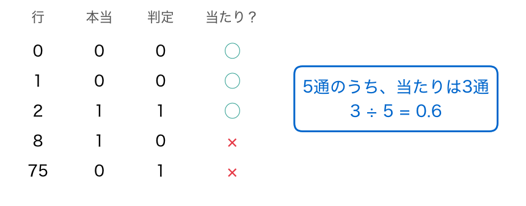

- 1通ずつ、本当の答えと判定を見比べ、同じなら当たり
- 当たりの通数を、全部の通数で割る。5,171通で行うと0.894

## 中身を見る：5通で正解率

2節 ⑤ 正解率●●●●○

```python
y = [0, 0, 1, 1, 0]      # 本当（行0・1・2・8・75）
p = [0, 0, 1, 0, 1]      # 判定
print(accuracy_score(y, p))
```

```
0.6
```

- 上の図の5通の本当と判定を、リストで渡した
- 5通のうち3通が当たりで、0.6

## 9割ほど当たる

2節 ⑤ 正解率●●●●●

- 「freeを含むなら迷惑」だけで、正解率は0.894
- 1行のルールで、9割ほどのメッセージを正しく判定できた
- これは、良いフィルターと言えるか

## 重要概念：if

2節 ⑥ 重要概念●

ifは、条件が成り立つ（True）ときだけ、字下げしたブロックを実行する。elseの下は、成り立たないときに動く。

## TODO①：探す語を替える

2節 ⑦ 探す語●

```python
# TODO: 'free' を 'xyz' に替えて実行する
word = 'free'
pred_x = []
for text in df['本文']:
    pred_x.append(rule(text, word))
df['判定_x'] = pred_x
print(df['判定_x'].sum())   # 迷惑と判定した通数
print(round(accuracy_score(df['迷惑'], df['判定_x']), 3))   # 正解率
```

- 2節と同じ4行。語を変数`word`にしまったので、替えるのは2行目だけ
- ’xyz’は、どのメッセージにも出てこない語
- 予想：迷惑と判定する通数は？ 正解率は？

## ここまでで分かったこと

2節 ⑧ 分かったこと●

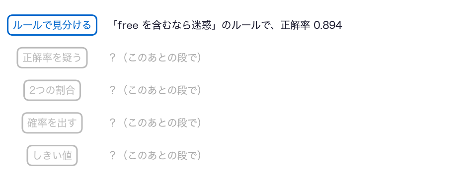

- まだ分からない：正解率0.894は、本当に良い数なのか

## ノートへ：0〜2節

2節 ⑨ ノートへ●

- 0〜2節のセルを上から実行し、スライドと同じ数が出るか確かめる
- TODO①：予想を書く → `'free'`を`'xyz'`に替えて実行 → 予想と比べる

動画の人は、ここで一時停止。

## 答え合わせ：TODO①

2節 10 答え合わせ●

```
0 0.874
```

- ’xyz’を含むメッセージは0通。全部を「普通」と判定する
- それでも、正解率は0.874

# 3. 正解率は信じてよい？

## 段2：正解率を疑う

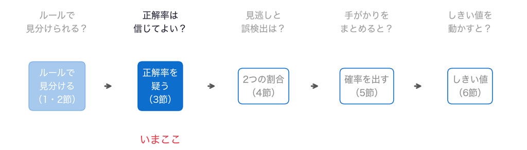

- 問い：正解率0.894は、信じてよいか
- 何も見分けないルールでも、0.874だった

## 前の段から

3節 ① 前の段から●

- freeのルールは、正解率0.894
- 何も迷惑と言わないルールでも、0.874
- 差はわずか。freeのルールは、何を当てて、何を外しているのか

## なぜ87%も当たる？

3節 ② 正解率の罠●○

- 迷惑は8通に1通（0.126）。普通は0.874
- 全部を「普通」と答えると、普通の4,518通がすべて当たる
- 正解率は、多い側（普通）の当たりで、ほとんど決まる

## 正解率は、1つにまとめすぎ

3節 ② 正解率の罠●●

- 正解率は、どこで当てて、どこで外したかを1つの数にまとめる
- 迷惑を1通も捕まえないフィルターでも、87%になる
- 当たりと外れを、種類に分けて数えたい

## 本当と判定で、4つのマス

3節 ③ 混同行列●○

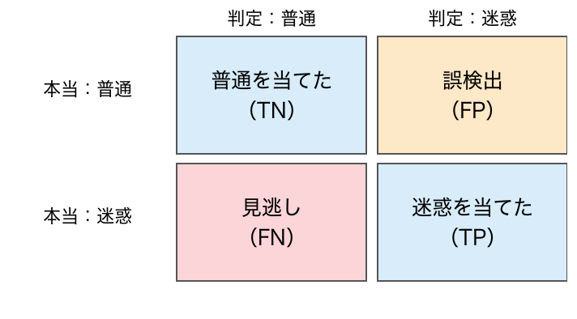

- 本当の答え（迷惑・普通）と、判定（迷惑・普通）の組で、4つに分ける

## 名前：混同行列

3節 ③ 混同行列●●

- 4つのマスに通数を数えた表を、混同行列（confusion matrix）と呼ぶ
- 見逃し：迷惑を普通と判定（FN、偽陰性）
- 誤検出：普通を迷惑と判定（FP、偽陽性）

## お手本：混同行列を数える

3節 ④ マスを数える●○○○○

```python
from sklearn.metrics import confusion_matrix
print(confusion_matrix(df['迷惑'], df['判定']))
```

```
[[4456   62]
 [ 484  169]]
```

- `confusion_matrix(本当, 判定)`：4つのマスの通数を、2×2の表で返す道具

## 1行ずつ：混同行列を数える

3節 ④ マスを数える●●○○○

```python
from sklearn.metrics import confusion_matrix
print(confusion_matrix(df['迷惑'], df['判定']))
```

- 1行目：`sklearn`の評価の道具の中から、`confusion_matrix`を呼び出す
- 2行目：本当の答えと判定を渡すと、2×2の表が返る。それを表示する
- 渡す順は、本当が先、判定が後

## confusion_matrixがしていること

3節 ④ マスを数える●●●○○

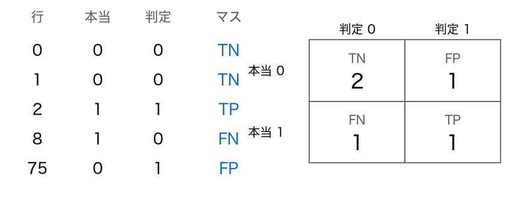

- 1通ずつ、本当（行）と判定（列）の組で、当てはまるマスに1を足す
- 5,171通で数えたのが、上の4つの数

## 中身を見る：5通の混同行列

3節 ④ マスを数える●●●●○

```python
y = [0, 0, 1, 1, 0]      # 本当（行0・1・2・8・75）
p = [0, 0, 1, 0, 1]      # 判定
print(confusion_matrix(y, p))
```

```
[[2 1]
 [1 1]]
```

- 上の図と同じ5通。TNが2、FP・FN・TPが1ずつ
- 上の行が本当の0（普通）、左の列が判定の0（普通）

## 並びは、普通が先

3節 ④ マスを数える●●●●●

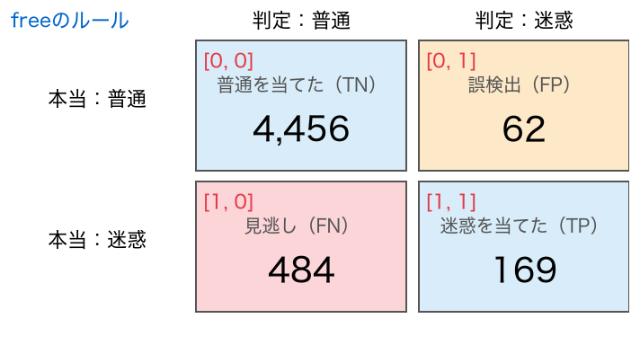

- `sklearn`は0（普通）、1（迷惑）の順。上の行・左の列が普通
- 迷惑を左上に置く本や記事もある。行と列の名前を先に確かめる

## freeのルールの混同行列

3節 ⑤ freeの混同行列●○○

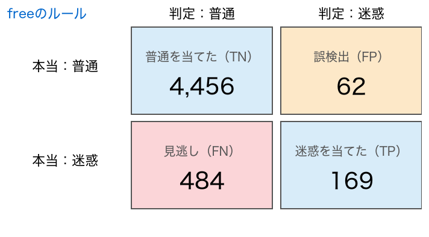

- 迷惑653通のうち、捕まえたのは169通。484通を見逃している

## 正解率の中身

3節 ⑤ freeの混同行列●●○

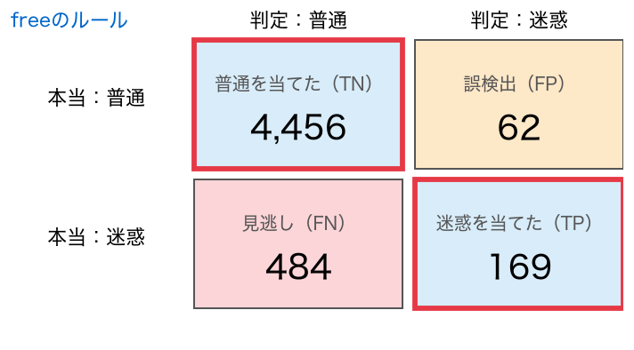

- 正解率は、当たりの2つのマス（169 + 4,456）を全体で割ったもの
- 当たりのほとんどは、普通を普通と言った4,456通

## 何も言わないルールの混同行列

3節 ⑤ freeの混同行列●●●

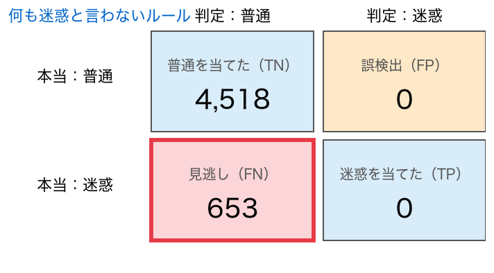

- 迷惑653通をすべて見逃す。それでも正解率は0.874

## 重要概念：混同行列

3節 ⑥ 重要概念●

正解率だけで見ない。混同行列の4つのマスを数え、見逃しと誤検出を分けて評価する。

## TODO②：探す語をprizeに

3節 ⑦ prize●

```python
# TODO: 'free' を 'prize' に替えて実行する
word = 'free'
pred_x = []
for text in df['本文']:
    pred_x.append(rule(text, word))
df['判定_x'] = pred_x
print(confusion_matrix(df['迷惑'], df['判定_x']))
```

- prizeは「賞品」。普通のメッセージにはめったに出ない語
- 予想：見逃しと誤検出は、freeと比べてどう変わる？

## ここまでで分かったこと

3節 ⑧ 分かったこと●

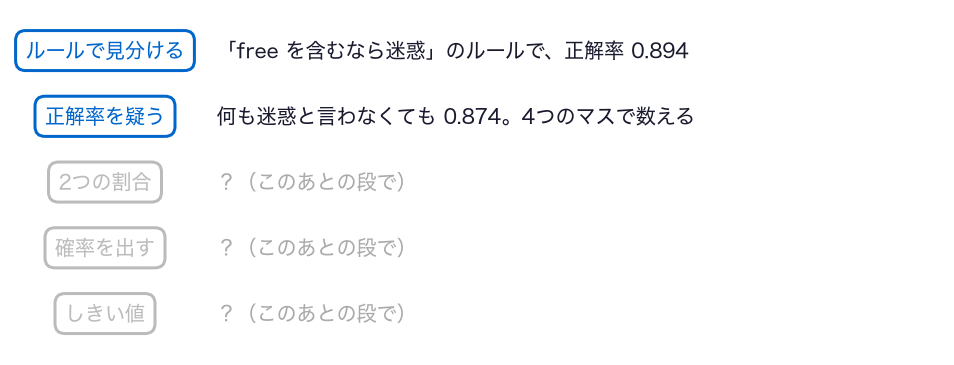

- まだ分からない：見逃しと誤検出を、どんな数で比べればよいか

## ノートへ：3節

3節 ⑨ ノートへ●

- 3節のセルを上から実行し、スライドと同じ数が出るか確かめる
- TODO②：予想を書く → `'free'`を`'prize'`に替えて実行 → 予想と比べる

動画の人は、ここで一時停止。

## 答え合わせ：TODO②

3節 10 答え合わせ●○

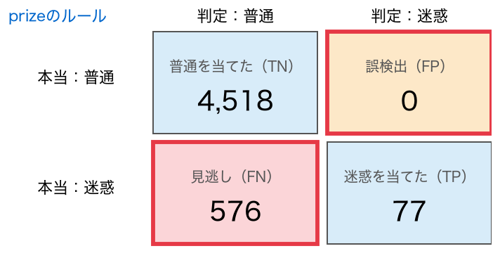

```
[[4518    0]
 [ 576   77]]
```

- 誤検出は0通。でも、見逃しは576通に増えた

## 誤検出と見逃しは、引っ張り合う

3節 10 答え合わせ●●

- prizeは、迷惑にしか出ない。だから、迷惑と言えば必ず当たる
- でも、prizeを含む迷惑は少ない。ほとんどを見逃す
- freeとprize、どちらが良いかは、2つの誤りをどう比べるかで決まる

# 4. 見逃しと誤検出は？

## 段3：2つの割合

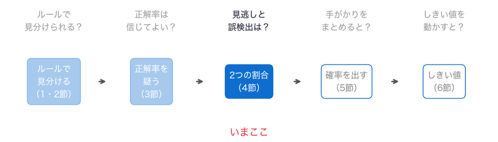

- 問い：見逃しと誤検出を、どんな数で比べればよいか
- freeは見逃しが多く、prizeは誤検出が0で見逃しがもっと多かった

## 前の段から

4節 ① 前の段から●

- 混同行列で、見逃しと誤検出を分けて数えられた
- でも、通数のままでは、迷惑の多いデータと少ないデータで比べにくい
- 割合にして、2つの数で評価する

## 再現率：迷惑のうち、捕まえた割合

4節 ② 再現率と適合率●○○○○○○

$$\text{再現率} = \frac{TP}{TP + FN}$$

- 本当に迷惑の通のうち、迷惑と判定できた割合
- 見逃しが少ないほど、1に近い。再現率（recall）と呼ぶ

## 適合率：迷惑と言って当たった割合

4節 ② 再現率と適合率●●○○○○○

$$\text{適合率} = \frac{TP}{TP + FP}$$

- 迷惑と判定した通のうち、本当に迷惑だった割合
- 誤検出が少ないほど、1に近い。適合率（precision）と呼ぶ

## お手本：2つの割合

4節 ② 再現率と適合率●●●○○○○

```python
from sklearn.metrics import recall_score, precision_score
print(round(recall_score(df['迷惑'], df['判定']), 3))      # 再現率
print(round(precision_score(df['迷惑'], df['判定']), 3))   # 適合率
```

```
0.259
0.732
```

- `recall_score`は再現率、`precision_score`は適合率を返す道具

## 1行ずつ：2つの割合

4節 ② 再現率と適合率●●●●○○○

```python
from sklearn.metrics import recall_score, precision_score
print(round(recall_score(df['迷惑'], df['判定']), 3))      # 再現率
print(round(precision_score(df['迷惑'], df['判定']), 3))   # 適合率
```

- 1行目：再現率の道具`recall_score`と、適合率の道具`precision_score`を呼び出す
- 2行目：本当の答えと判定を渡し、再現率を出す
- 3行目：同じ2つを渡し、適合率を出す

## 2つの道具がしていること

4節 ② 再現率と適合率●●●●●○○

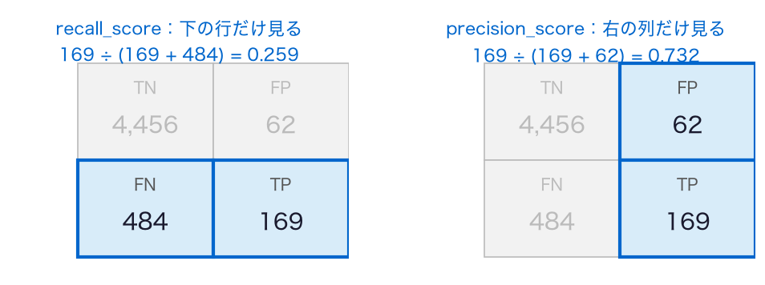

- 再現率は、下の行（本当に迷惑）だけを見る
- 適合率は、右の列（迷惑と判定）だけを見る

## 中身を見る：5通の2つの割合

4節 ② 再現率と適合率●●●●●●○

```python
y = [0, 0, 1, 1, 0]      # 本当（行0・1・2・8・75）
p = [0, 0, 1, 0, 1]      # 判定
print(recall_score(y, p), precision_score(y, p))
```

```
0.5 0.5
```

- 再現率：本当に迷惑の2通（行2・8）のうち、迷惑と判定したのは1通
- 適合率：迷惑と判定した2通（行2・75）のうち、本当に迷惑は1通

## freeのルールの2つの割合

4節 ② 再現率と適合率●●●●●●●

- 再現率0.259：迷惑の4通に1通しか捕まえていない
- 適合率0.732：迷惑と言った4通のうち、3通ほどは本当に迷惑
- 正解率0.894からは見えなかった弱さが、再現率に出る

## お手本：prizeのルールの2つの割合

4節 ③ 語のルール●○

```python
pred_p = []
for text in df['本文']:
    pred_p.append(rule(text, 'prize'))
df['判定_p'] = pred_p
print(round(recall_score(df['迷惑'], df['判定_p']), 3))
print(round(precision_score(df['迷惑'], df['判定_p']), 3))
```

```
0.118
1.0
```

- prizeは適合率1.0だが、再現率0.118
- 1つの語では、迷惑の一部しか捕まえられない

## 1行ずつ：prizeのルール

4節 ③ 語のルール●●

```python
pred_p = []
for text in df['本文']:
    pred_p.append(rule(text, 'prize'))
df['判定_p'] = pred_p
print(round(recall_score(df['迷惑'], df['判定_p']), 3))
print(round(precision_score(df['迷惑'], df['判定_p']), 3))
```

- 1〜4行目：2節と同じ形。探す語をprizeにして、列「判定_p」を作る
- 5・6行目：再現率と適合率を出す

## 迷惑には、番号が並ぶ

4節 ④ 数字を数える●○○○○○○○○○

- 迷惑の本文には、電話番号や、返信先の短い番号が書いてある
- 普通のメッセージに、数字はあまり出てこない
- 本文の中の数字を数えたら、手がかりにならないか

## 道具：文字列も、forで1字ずつ

4節 ④ 数字を数える●●○○○○○○○○

```python
for ch in 'a1b2':
    print(ch, ch.isdigit())
```

```
a False
1 True
b False
2 True
```

- `for ch in 文字列:`で、1字ずつ取り出せる。`isdigit()`は数字ならTrue

## お手本：数字を数える関数

4節 ④ 数字を数える●●●○○○○○○○

```python
def n_digits(text):
    n = 0
    for ch in text:          # 本文を1字ずつ
        if ch.isdigit():     # 数字なら
            n = n + 1        # 1を足す
    return n

print(n_digits('call 08707509020 now'))
```

```
11
```

## 1行ずつ：数字を数える①

4節 ④ 数字を数える●●●●○○○○○○

```python
def n_digits(text):
    n = 0
    for ch in text:          # 本文を1字ずつ
        if ch.isdigit():     # 数字なら
            n = n + 1        # 1を足す
    return n

print(n_digits('call 08707509020 now'))
```

- 1行目：関数`n_digits`を作る。入力は本文`text`
- 2行目：数えた数をためる変数`n`を、0から始める

## 1行ずつ：数字を数える②

4節 ④ 数字を数える●●●●●○○○○○

```python
def n_digits(text):
    n = 0
    for ch in text:          # 本文を1字ずつ
        if ch.isdigit():     # 数字なら
            n = n + 1        # 1を足す
    return n

print(n_digits('call 08707509020 now'))
```

- 3行目：本文を1字ずつ取り出して`ch`に入れる
- 4行目：`ch`が数字のときだけ、5行目へ進む
- 5行目：`n`に1を足して、`n`にしまい直す

## 1行ずつ：数字を数える③

4節 ④ 数字を数える●●●●●●○○○○

```python
def n_digits(text):
    n = 0
    for ch in text:          # 本文を1字ずつ
        if ch.isdigit():     # 数字なら
            n = n + 1        # 1を足す
    return n

print(n_digits('call 08707509020 now'))
```

- 6行目：全部の字を見終わったら`n`を返す。字下げが`for`の外なので、最後に1回だけ動く
- 8行目：電話番号の入った本文で試す

## 中身を見る：1字ずつのnの変化

4節 ④ 数字を数える●●●●●●●○○○

```python
n = 0
for ch in 'call 0870':
    if ch.isdigit():
        n = n + 1
    print(ch, n)
```

```
c 0
a 0
l 0
l 0
  0
0 1
8 2
7 3
0 4
```

- 数字の字のところでだけ、`n`が1つ増える

## お手本：数字の数の列

4節 ④ 数字を数える●●●●●●●●○○

```python
nd = []
for text in df['本文']:
    nd.append(n_digits(text))
df['数字'] = nd
print(df.groupby('迷惑')['数字'].mean().round(1))
```

```
迷惑
0     0.3
1    15.5
```

- 迷惑は平均15.5字、普通は平均0.3字

## 1行ずつ：数字の数の列

4節 ④ 数字を数える●●●●●●●●●○

```python
nd = []
for text in df['本文']:
    nd.append(n_digits(text))
df['数字'] = nd
print(df.groupby('迷惑')['数字'].mean().round(1))
```

- 1〜4行目：2節の判定と同じ形。1通ずつ`n_digits`で数え、リストにためて列「数字」にする
- 5行目：`groupby('迷惑')`で迷惑（1）と普通（0）に分け、列「数字」の平均を出す
- `round(1)`で、小数第1位までに丸める

## 数字の数で、ほぼ分かれる

4節 ④ 数字を数える●●●●●●●●●●

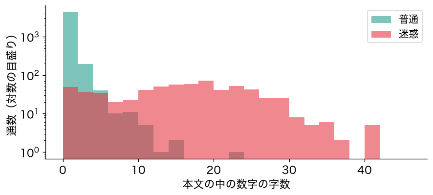

- 普通（緑）はほとんどが0字。迷惑（赤）は、数字が何字も並ぶ通が多い

## お手本：数字のルール

4節 ⑤ 数字のルール●○○○

```python
pred_d = []
for n in df['数字']:
    if n >= 5:
        pred_d.append(1)     # 5字以上なら迷惑
    else:
        pred_d.append(0)
df['判定_数字'] = pred_d
print(confusion_matrix(df['迷惑'], df['判定_数字']))
print(round(recall_score(df['迷惑'], df['判定_数字']), 3))
print(round(precision_score(df['迷惑'], df['判定_数字']), 3))
```

```
[[4479   39]
 [  96  557]]
0.853
0.935
```

## 1行ずつ：数字のルール①

4節 ⑤ 数字のルール●●○○

```python
pred_d = []
for n in df['数字']:
    if n >= 5:
        pred_d.append(1)     # 5字以上なら迷惑
    else:
        pred_d.append(0)
df['判定_数字'] = pred_d
print(confusion_matrix(df['迷惑'], df['判定_数字']))
print(round(recall_score(df['迷惑'], df['判定_数字']), 3))
print(round(precision_score(df['迷惑'], df['判定_数字']), 3))
```

- 2行目：列「数字」から、1通ずつ字数を取り出して`n`に入れる
- 3〜6行目：`n`が5以上なら1、そうでなければ0を、`pred_d`の後ろに足す
- `rule`と違い、ifを関数に入れず、くり返しの中に直接書いた

## 1行ずつ：数字のルール②

4節 ⑤ 数字のルール●●●○

```python
pred_d = []
for n in df['数字']:
    if n >= 5:
        pred_d.append(1)     # 5字以上なら迷惑
    else:
        pred_d.append(0)
df['判定_数字'] = pred_d
print(confusion_matrix(df['迷惑'], df['判定_数字']))
print(round(recall_score(df['迷惑'], df['判定_数字']), 3))
print(round(precision_score(df['迷惑'], df['判定_数字']), 3))
```

- 7行目：リストを列「判定_数字」にする
- 8行目：混同行列を表示する
- 9・10行目：再現率と適合率を表示する

## 見逃しが、484通から96通に

4節 ⑤ 数字のルール●●●●

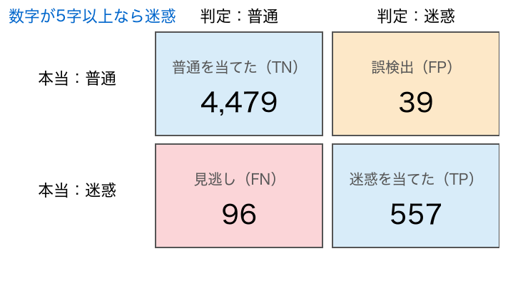

- 再現率0.853、適合率0.935。freeのルールより、どちらも良い

## 重要：2つの誤りの重さは違う

4節 ⑥ 誤りの重さ●

見逃しは、迷惑が届いてしまう。誤検出は、大事な連絡が届かない。重さが違うので、2つを分けて見る。

## TODO③：数字のしきいを替える

4節 ⑦ しきいを替える●

```python
# TODO: 5 を 1 に替えて実行する
k = 5
pred_x = []
for n in df['数字']:
    if n >= k:
        pred_x.append(1)
    else:
        pred_x.append(0)
df['判定_x'] = pred_x
print(confusion_matrix(df['迷惑'], df['判定_x']))
print(round(recall_score(df['迷惑'], df['判定_x']), 3))
print(round(precision_score(df['迷惑'], df['判定_x']), 3))
```

- 予想：数字が1字でもあれば迷惑、にすると、再現率と適合率はどうなる？

## ここまでで分かったこと

4節 ⑧ 分かったこと●

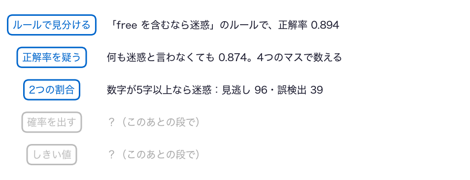

- まだ分からない：数字と語を、まとめて使えないか

## ノートへ：4節

4節 ⑨ ノートへ●

- 4節のセルを上から実行し、スライドと同じ数が出るか確かめる
- TODO③：予想を書く → `5`を`1`に替えて実行 → 予想と比べる

動画の人は、ここで一時停止。

## 答え合わせ：TODO③

4節 10 答え合わせ●○

```
5字以上 [[4479, 39], [96, 557]] (0.853, 0.935)
1字以上 [[3803, 715], [39, 614]] (0.94, 0.462)
```

- 再現率は0.94に上がった。でも誤検出が715通に増え、適合率は0.462に下がった

## しきいで、2つの割合が入れ替わる

4節 10 答え合わせ●●

- しきいを下げると、迷惑を広く捕まえる。普通も巻き込む
- しきいを上げると、確かなものだけ捕まえる。見逃しが増える
- 再現率と適合率の両方を、同時に1にはしにくい

# 5. 手がかりをまとめると？

## 段4：確率を出す

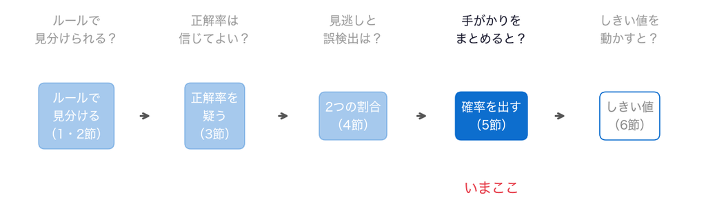

- 問い：数字と語の手がかりを、まとめて1つの確率にできないか
- これまでは、手がかりを1つずつ使うルールだった

## 前の段から

5節 ① 前の段から●

- 数字のルールは、見逃し96・誤検出39
- 迷惑の決まり文句（free、claim、prize…）も、手がかりになった
- 手がかりを、迷惑である確率にまとめ、確率で判定したい

## 同じことを、何度もやる

5節 ② 手がかりの列●○○○○○○

- 語ごとに、1通ずつ`rule`で判定して、リストにためた
- 語を15個にするなら、同じ4行を15回書くことになる
- 1回分を関数にまとめ、語をくり返しの外から渡す

## お手本：1つの語の列を作る関数

5節 ② 手がかりの列●●○○○○○

```python
def rule_col(word):
    pred = []
    for text in df['本文']:
        pred.append(rule(text, word))
    return pred
```

- 入力は語、出力は全部の通の1/0のリスト。2節の4行と同じ中身

## 1行ずつ：語の列を作る関数

5節 ② 手がかりの列●●●○○○○

```python
def rule_col(word):
    pred = []
    for text in df['本文']:
        pred.append(rule(text, word))
    return pred
```

- 1行目：関数`rule_col`を作る。入力は探す語`word`
- 2〜4行目：2節の4行と同じ。`'free'`のところが`word`になった
- 5行目：ためたリスト`pred`を返す

## お手本：15語の列

5節 ② 手がかりの列●●●●○○○

```python
words = ['free', 'txt', 'claim', 'prize', 'call', 'win', '£',
         'www', 'urgent', 'mobile', 'reply', 'stop', 'cash',
         'service', 'new']
for w in words:
    df[w] = rule_col(w)          # 語を含めば1、なければ0
cols = ['数字'] + words
print(len(words), '語と数字で', len(cols), '本の手がかり')
```

```
15 語と数字で 16 本の手がかり
```

- 迷惑によく出てくる語を、15個選んだ。数字の数と合わせて16本

## 1行ずつ：15語の列①

5節 ② 手がかりの列●●●●●○○

```python
words = ['free', 'txt', 'claim', 'prize', 'call', 'win', '£',
         'www', 'urgent', 'mobile', 'reply', 'stop', 'cash',
         'service', 'new']
for w in words:
    df[w] = rule_col(w)          # 語を含めば1、なければ0
cols = ['数字'] + words
print(len(words), '語と数字で', len(cols), '本の手がかり')
```

- 1〜3行目：15個の語を並べたリストを`words`にしまう。長いので3行に折り返した

## 1行ずつ：15語の列②

5節 ② 手がかりの列●●●●●●○

```python
words = ['free', 'txt', 'claim', 'prize', 'call', 'win', '£',
         'www', 'urgent', 'mobile', 'reply', 'stop', 'cash',
         'service', 'new']
for w in words:
    df[w] = rule_col(w)          # 語を含めば1、なければ0
cols = ['数字'] + words
print(len(words), '語と数字で', len(cols), '本の手がかり')
```

- 4行目：`words`から1語ずつ取り出して`w`に入れる
- 5行目：その語を含めば1・なければ0のリストを作り、語の名前の列にする
- 6行目：「数字」と15語をつないだリスト（`+`でつなぐ）。7行目：本数を表示

## 中身を見る：語の列

5節 ② 手がかりの列●●●●●●●

```python
df[['free', 'txt', 'claim', 'call', '数字']].head(3)
```

|  | free | txt | claim | call | 数字 |
| --- | --- | --- | --- | --- | --- |
| 0 | 0 | 0 | 0 | 0 | 0 |
| 1 | 0 | 0 | 0 | 0 | 0 |
| 2 | 1 | 1 | 0 | 0 | 25 |

- 語の列は、その語を含めば1。3通めは、freeを含むので1

## 0と1を、確率で当てる

5節 ③ 確率の式●○○

$$z_i = b_0 + b_1 x_{i1} + \cdots + b_{16} x_{i,16}, \qquad
\hat{p}_i = \frac{1}{1 + e^{-z_i}}$$

- $x_{i1}, \dots, x_{i,16}$は、$i$番目の通の16本の手がかり
- 1次式の値$z_i$を、シグモイドで0〜1に収める。$\hat{p}_i$が迷惑である確率
- この式の作り方を、ロジスティック回帰（logistic regression）と呼ぶ

## シグモイドがしていること

5節 ③ 確率の式●●○

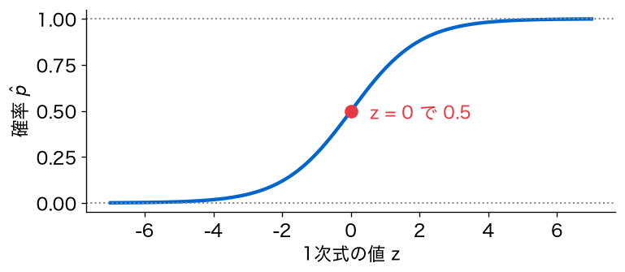

- $z$が大きいほど1に、小さいほど0に近づく。$z = 0$でちょうど0.5
- どんな$z$でも、0〜1の間に収まる

## 確率にも、交差検証

5節 ③ 確率の式●●●

- 式を作った通で確率を出すと、甘くなる（第2回の過学習）
- 5つの組に分け、1つの組を残して式を作り、残した組の確率を出す（第4回）
- 第4回は自分で書いた。今日は、道具`cross_val_predict`で行う

## お手本：交差検証で確率を出す

5節 ④ 確率を出す●○○○○○○

```python
from sklearn.linear_model import LogisticRegression
from sklearn.model_selection import cross_val_predict
p = cross_val_predict(LogisticRegression(), df[cols], df['迷惑'],
                      cv=5, method='predict_proba')
df['確率'] = p[:, 1]
print(round(df['確率'].min(), 3), round(df['確率'].max(), 3))
```

```
0.005 1.0
```

- `method='predict_proba'`：判定（0か1）ではなく、確率を返す
- 確率は0.005〜1.0。0〜1をはみ出さない

## 1行ずつ：確率を出す①

5節 ④ 確率を出す●●○○○○○

```python
from sklearn.linear_model import LogisticRegression
from sklearn.model_selection import cross_val_predict
p = cross_val_predict(LogisticRegression(), df[cols], df['迷惑'],
                      cv=5, method='predict_proba')
df['確率'] = p[:, 1]
print(round(df['確率'].min(), 3), round(df['確率'].max(), 3))
```

- 1・2行目：ロジスティック回帰の道具と、交差検証の道具を呼び出す
- 3・4行目：式の作り方、16本の手がかりの列、答えの列を渡す。`cv=5`は5つの組
- `method='predict_proba'`で、全部の通の確率が`p`に返る

## 1行ずつ：確率を出す②

5節 ④ 確率を出す●●●○○○○

```python
from sklearn.linear_model import LogisticRegression
from sklearn.model_selection import cross_val_predict
p = cross_val_predict(LogisticRegression(), df[cols], df['迷惑'],
                      cv=5, method='predict_proba')
df['確率'] = p[:, 1]
print(round(df['確率'].min(), 3), round(df['確率'].max(), 3))
```

- 5行目：`p`の右の列（迷惑の確率）を取り出し、列「確率」にしまう
- 6行目：確率のいちばん小さい値と、いちばん大きい値を表示する

## predict_probaがしていること

5節 ④ 確率を出す●●●●○○○

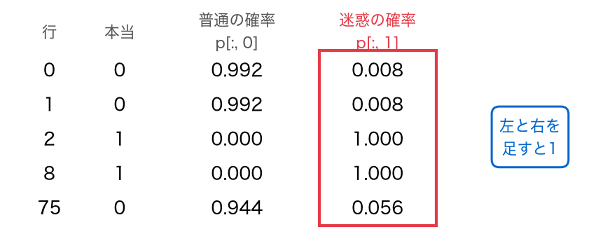

- 1通に2つの確率（普通の確率、迷惑の確率）。足すと1
- `p[:, 1]`は「すべての行の、1番の列」。迷惑の確率だけを取り出す

## 中身を見る：5通の2つの確率

5節 ④ 確率を出す●●●●●○○

```python
print(p[[0, 1, 2, 8, 75]].round(3))
```

```
[[0.992 0.008]
 [0.992 0.008]
 [0.    1.   ]
 [0.    1.   ]
 [0.944 0.056]]
```

- `p[[0, 1, 2, 8, 75]]`で、5つの行を取り出した。左が普通、右が迷惑の確率
- 行2・8は迷惑で、右の列が1.0

## cross_val_predictがしていること

5節 ④ 確率を出す●●●●●●○

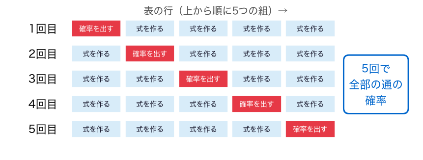

- 表を上から順に5つの組に分け、4つの組で式を作り、残りの組の確率を出す
- 5回で、どの通も、自分を見ていない式から確率をもらう

## 中身を見る：確率の列

5節 ④ 確率を出す●●●●●●●

```python
df[['迷惑', '確率']].head(3)
```

|  | 迷惑 | 確率 |
| --- | --- | --- |
| 0 | 0 | 0.008459 |
| 1 | 0 | 0.008459 |
| 2 | 1 | 1.000000 |

- 1通に1つずつ、確率が付いた。迷惑（1）の行ほど確率が高い

## お手本：確率を描く

5節 ⑤ 確率を描く●○○○○

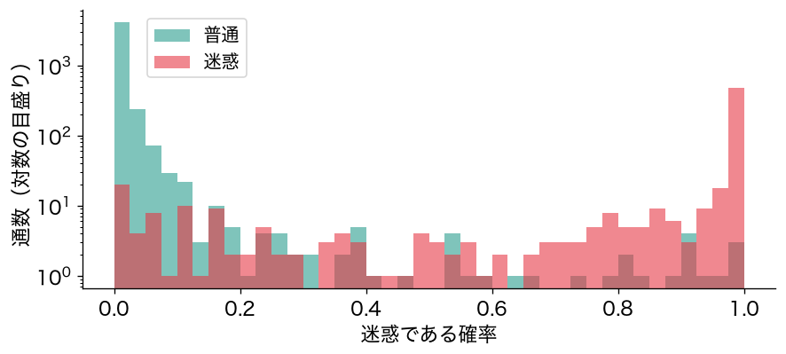

```python
ham = df[df['迷惑'] == 0]['確率']
spam = df[df['迷惑'] == 1]['確率']
plt.hist(ham, bins=40, alpha=0.6, label='普通')
plt.hist(spam, bins=40, alpha=0.6, label='迷惑')
plt.yscale('log')
plt.xlabel('迷惑である確率')
plt.ylabel('通数（対数の目盛り）')
plt.legend()
plt.show()
```

## 1行ずつ：確率を描く①

5節 ⑤ 確率を描く●●○○○

```python
ham = df[df['迷惑'] == 0]['確率']
spam = df[df['迷惑'] == 1]['確率']
plt.hist(ham, bins=40, alpha=0.6, label='普通')
plt.hist(spam, bins=40, alpha=0.6, label='迷惑')
plt.yscale('log')
plt.xlabel('迷惑である確率')
plt.ylabel('通数（対数の目盛り）')
plt.legend()
plt.show()
```

- 1行目：普通の行だけを取り出し、確率の列を`ham`にしまう
- 2行目：迷惑の行の確率を`spam`にしまう

## 1行ずつ：確率を描く②

5節 ⑤ 確率を描く●●●○○

```python
ham = df[df['迷惑'] == 0]['確率']
spam = df[df['迷惑'] == 1]['確率']
plt.hist(ham, bins=40, alpha=0.6, label='普通')
plt.hist(spam, bins=40, alpha=0.6, label='迷惑')
plt.yscale('log')
plt.xlabel('迷惑である確率')
plt.ylabel('通数（対数の目盛り）')
plt.legend()
plt.show()
```

- 3・4行目：確率を40の区間に分けて柱を描く（`hist`）
- `alpha=0.6`で半透明にし、重なりを見せる。`label`は凡例に出す名前

## 1行ずつ：確率を描く③

5節 ⑤ 確率を描く●●●●○

```python
ham = df[df['迷惑'] == 0]['確率']
spam = df[df['迷惑'] == 1]['確率']
plt.hist(ham, bins=40, alpha=0.6, label='普通')
plt.hist(spam, bins=40, alpha=0.6, label='迷惑')
plt.yscale('log')
plt.xlabel('迷惑である確率')
plt.ylabel('通数（対数の目盛り）')
plt.legend()
plt.show()
```

- 5行目：縦軸を10倍ごとの目盛りにする
- 6〜8行目：軸の名前と凡例を付ける。9行目：図を表示する

## 迷惑ほど、確率が高い

5節 ⑤ 確率を描く●●●●●

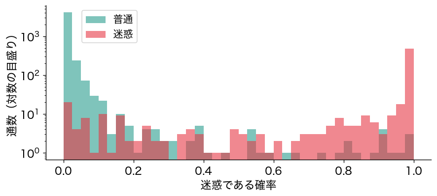

- 普通（緑）は0のまわり、迷惑（赤）は1のまわりに多い
- `plt.yscale('log')`：縦軸を10倍ごとの目盛りに。少ない迷惑も見える

## お手本：確率を切って判定する

5節 ⑥ 0.5で切る●○○○○○○

```python
df['判定_式'] = (df['確率'] >= 0.5).astype(int)
print(confusion_matrix(df['迷惑'], df['判定_式']))
print(round(recall_score(df['迷惑'], df['判定_式']), 3))
print(round(precision_score(df['迷惑'], df['判定_式']), 3))
```

```
[[4495   23]
 [  83  570]]
0.873
0.961
```

- `df['確率'] >= 0.5`：確率が0.5以上ならTrue。`astype(int)`で1と0に直す（0節と同じ）

## 1行ずつ：確率を切る①

5節 ⑥ 0.5で切る●●○○○○○

```python
df['判定_式'] = (df['確率'] >= 0.5).astype(int)
print(confusion_matrix(df['迷惑'], df['判定_式']))
print(round(recall_score(df['迷惑'], df['判定_式']), 3))
print(round(precision_score(df['迷惑'], df['判定_式']), 3))
```

- `df['確率'] >= 0.5`：1通ずつ0.5と比べ、以上ならTrueの列
- `astype(int)`で1と0に直し、列「判定_式」にしまう

## 1行ずつ：確率を切る②

5節 ⑥ 0.5で切る●●●○○○○

```python
df['判定_式'] = (df['確率'] >= 0.5).astype(int)
print(confusion_matrix(df['迷惑'], df['判定_式']))
print(round(recall_score(df['迷惑'], df['判定_式']), 3))
print(round(precision_score(df['迷惑'], df['判定_式']), 3))
```

- 2行目：混同行列を表示する
- 3・4行目：再現率と適合率を表示する

## 中身を見る：確率と判定

5節 ⑥ 0.5で切る●●●●○○○

```python
df[['確率', '判定_式']].head(3)
```

|  | 確率 | 判定_式 |
| --- | --- | --- |
| 0 | 0.008459 | 0 |
| 1 | 0.008459 | 0 |
| 2 | 1.000000 | 1 |

- 0.5以上の行だけが1になった

## 0.5で切った混同行列

5節 ⑥ 0.5で切る●●●●●○○

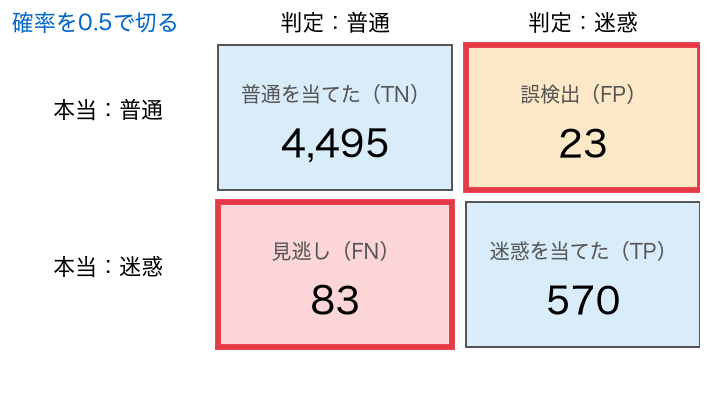

- 迷惑である確率が半分以上なら、迷惑と判定する
- 見逃し83通、誤検出23通

## ルールに、両方で勝つ

5節 ⑥ 0.5で切る●●●●●●○

```
数字のルール (0.853, 0.935)  見逃し 96  誤検出 39
確率（0.5）   (0.873, 0.961)  見逃し 83  誤検出 23
```

- 数字のルール（見逃し96・誤検出39）より、見逃しも誤検出も少ない
- 16本の手がかりを、1つの確率にまとめた効果

## 重要：確率を切って判定する

5節 ⑥ 0.5で切る●●●●●●●

ロジスティック回帰は、手がかりの1次式をシグモイドで0〜1に収め、迷惑である確率を出す。確率をしきい値で切ると、判定になる。

## TODO④：手がかりから数字を外す

5節 ⑦ 手がかりを外す●

```python
# TODO: ['数字'] + words を words に替えて実行する
cols_x = ['数字'] + words
p = cross_val_predict(LogisticRegression(), df[cols_x], df['迷惑'],
                      cv=5, method='predict_proba')
df['判定_x'] = (p[:, 1] >= 0.5).astype(int)
print(confusion_matrix(df['迷惑'], df['判定_x']))
```

- 予想：15語だけにすると、見逃しは83通から増える？ 減る？

## ここまでで分かったこと

5節 ⑧ 分かったこと●

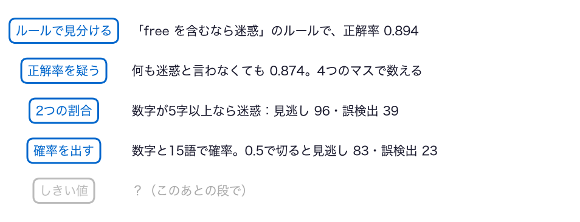

- まだ分からない：0.5で切ったのは、正しかったのか

## ノートへ：5節

5節 ⑨ ノートへ●

- 5節のセルを上から実行し、スライドと同じ数が出るか確かめる
- TODO④：予想を書く → `['数字'] + words`を`words`に替えて実行 → 予想と比べる

動画の人は、ここで一時停止。

## 答え合わせ：TODO④

5節 10 答え合わせ●

```
数字と15語 [[4495, 23], [83, 570]]
15語だけ   [[4479, 39], [175, 478]]
```

- 15語だけでは、見逃しが175通に増えた
- 16本の中で、数字の数がいちばん効く手がかり